## Model initialisation

The function `madingley_init()` initialises a model run by generating a cohort and stock data set. Both data sets are returned as data frames in a list object (here named: `mdata`) after the `madingley_init()` finishes. The cohort data set contains functional information for all cohorts (i.e. heterotrophs) needed to run a Madingley simulation (`mdata$cohorts`). The stock data set holds the functional information concerning the stocks (i.e. photo-autotrophs) (`mdata$stocks`). The generated data sets are based on the functional definitions defined in `cohort_def` (cohort definitions) and `stock_def` (stock definitions). `spatial_window` defines the boundaries of the spatial location, formatted as a vector containing four coordinates in the following order: 1) minimum longitude, 2) maximum longitude, 3) minimum latitude and 4) maximum latitude. The R code shown below illustrates the use of the `madingley_init()` function for an area that includes the Serengeti.

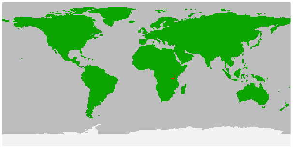

```r
# Load package
library(MadingleyR)

# Spatial model domain = c(min_long, max_long, min_lat, max_lat)
spatial_window = c(31, 35, -5, -1)

# plot the spatial window to check selection
plot_spatialwindow(spatial_window)
```

*spatial window plotted on top of land mask*

```r
# Load inputs manually
madingley_inputs( ) # prints the possible input options to the R console
sptl_inp = madingley_inputs('spatial inputs')
chrt_def = madingley_inputs('cohort definition')
stck_def = madingley_inputs('stock definition')
mdl_prms = madingley_inputs('model parameters') # useful later for running the model

# Initialise model the model using the pre-loaded inputs
mdata = madingley_init(spatial_window = spatial_window,
                       cohort_def = chrt_def,
                       stock_def = stck_def,
                       spatial_inputs = sptl_inp)
```

The returned `mdata` object will contain all cohorts and stocks (`data.frame`). In addition, the spatial window will be attached, making sure any consecutive model run will use the same spatial window.